# Series02-Rstudio

2025-09-25

IEAP-2025 Series 02 Rstudio Data mining and statistical tests

```r
nonUse <- read.csv("data/NonUse.csv")
```

# 1 Correlations and linear regression

In this series of exercises, you will explore correlations and linear regression, using a dataset from a real experiment.

## 1.1 The problem

You want to know if there is a relationship between the nonuse of the proximal part of the upper limb (PANU) and the nonuse of the shoulder (SANU) or the elbow (EENU).

## 1.2 The data

As you will see, the data is far from perfect, but this is the reality of experimental data, especially in the case of clinical data.

Download the file NonUse.csv from the course Moodle.

This file contains measures of upper extremity nonuse:

- PANU: Proximal Arm Non Use
- SANU: Shoulder Antepulsion Non Use
- EENU: Elbow Extension Non Use In your notebook, make a clear description of the experiment, the variables and the data. Do not forget to give the units of each variable, and the range of possible values.

## 1.3 Corelation analysis

Below are some questions to guide your analysis.

- Is PANU correlated with SANU and/or EENU?

```r
cor.test(nonUse$PANU, nonUse$SANU, method = "spearman")
```

```
##
##  Spearman's rank correlation rho
##
## data:  nonUse$PANU and nonUse$SANU
## S = 1192838, p-value = 0.001718
## alternative hypothesis: true rho is not equal to 0
## sample estimates:
##       rho
## 0.2160221
```

- Visualize the PANU-SANU relationship (and the PANU-EENU relationship)

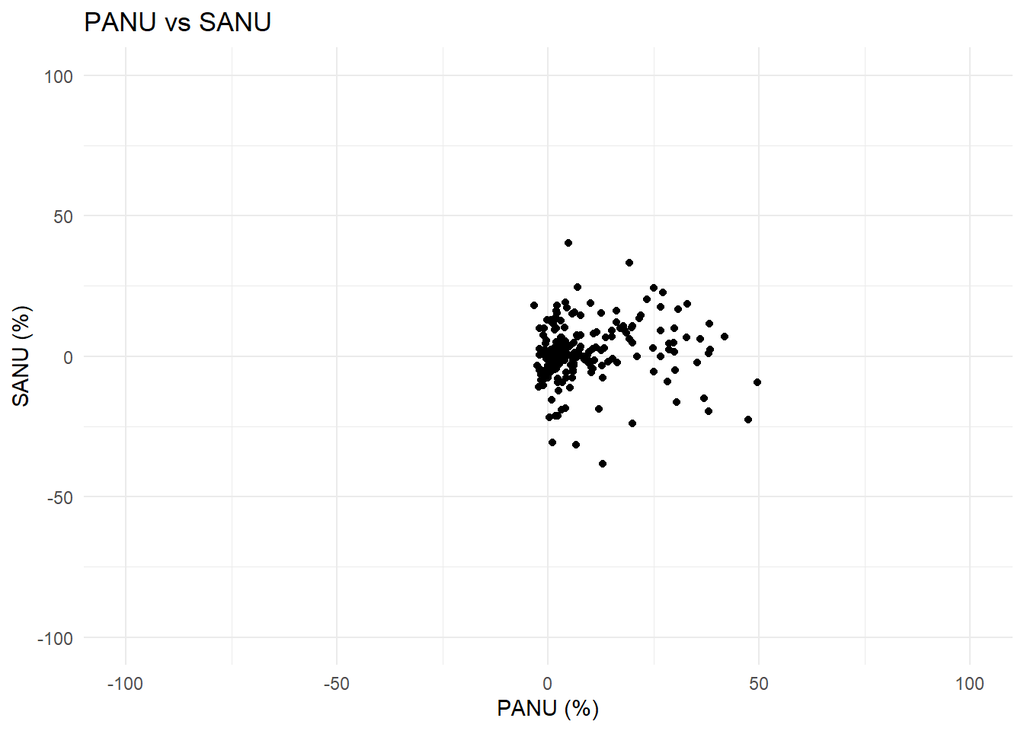

```r
library(ggplot2)
ggplot(nonUse, aes(x=PANU, y=SANU)) +
  geom_point() +
  xlim(-100, 100) +
  ylim(-100, 100) +
  labs(title = "PANU vs SANU", x = "PANU (%)", y = "SANU (%)") +
  theme_minimal()
```

- Perform a linear regression for PANU-SANU (and for PANU-EENU)

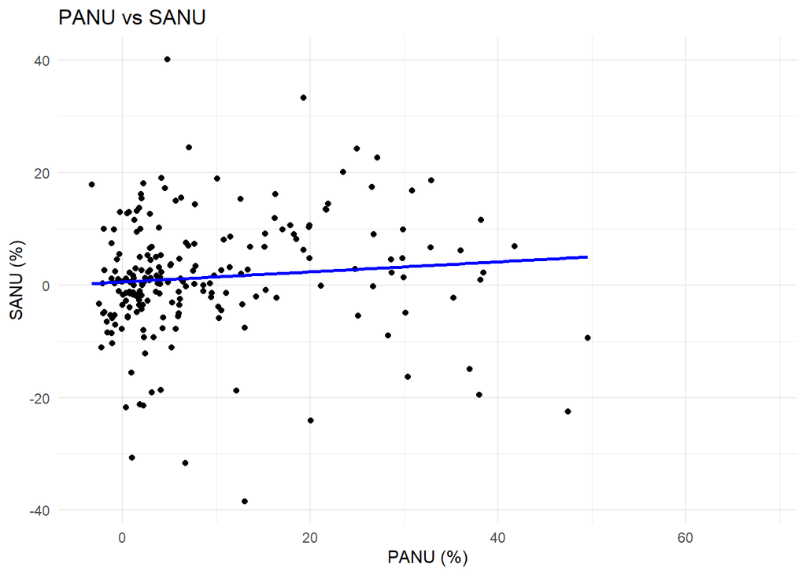

```r
library(ggplot2)
ggplot(nonUse, aes(x=PANU, y=SANU)) +
  geom_point() +
  geom_smooth(method = "lm", formula = y~x, color = 'blue', se = FALSE) +
  labs(title = "PANU vs SANU", x = "PANU (%)", y = "SANU (%)") +
  theme_minimal()
```

- Give the regression equations: PANU = a * SANU + b and PANU = a * EENU + b

```r
lm_sanu <- lm(SANU ~ PANU, data = nonUse)
summary(lm_sanu)
```

```
##
## Call:
## lm(formula = SANU ~ PANU, data = nonUse)
##
## Residuals:
##     Min      1Q  Median      3Q     Max
## -40.168  -4.593  -0.070   5.928  39.162
##
## Coefficients:
##             Estimate Std. Error t value Pr(>|t|)
## (Intercept)  0.58605    0.93615   0.626    0.532
## PANU         0.08933    0.06509   1.372    0.171
##
## Residual standard error: 10.55 on 207 degrees of freedom
##   (223 observations effacées parce que manquantes)
## Multiple R-squared:  0.009016,   Adjusted R-squared:  0.004229
## F-statistic: 1.883 on 1 and 207 DF,  p-value: 0.1714
```

```r
coef(lm_sanu)
```

```
## (Intercept)        PANU
##  0.58605205  0.08932839
```

```r
slope <- coef(lm_sanu)[2]
intercept <- coef(lm_sanu)[1]
cat("Regression equation : SANU =", slope, "* PANU +", intercept, "\n")
```

```
## Regression equation : SANU = 0.08932839 * PANU + 0.5860521
```

- Summarize your results as you would do in your master’s thesis report, or as in a scientific article (e.g., What sentence will you write in the article explaining your result?).
- What are the limits of your analysis?

# 2 Statistical tests: comparison of medians (or means?)

In this series of exercises, you will explore how to compare two groups of data, using non-parametric tests (or parametric tests… if it makes sense to do so).

## 2.1 Make clear what is a statistical test, and when to use it.

Below are some questions to guide your analysis. You can answer them in your notebook, with a short sentence for each question.

- What is a median? A mean?
- What is a variance? A standard deviation?
- What is a normal distribution?
- What is a statistical test?
- When to use a statistical test?
- What is a parametric test? A non-parametric test?
- What are the assumptions of parametric tests?
- What are the assumptions of non-parametric tests?
- What is a p-value?
- What is the risk of error when using a statistical test?
- What is the difference between a paired and an unpaired test? You can use your favorite LLM, book or web site to answer these questions, but you have to provide at least one reference for each answer (book, article, URL, LLM prompt, etc.).

## 2.2 Effect of treatment over time

This is a very classical question in clinical or sport research: does a treatment-training have an effect over time?

To answer this question scientifically, measurements must be taken before and after treatment, and possibly later, in order to assess whether the effect is lasting or not.

### 2.2.1 The data

Download the file PrePost.csv

This file contains before/after measurements. The treatment is a rehabilitation training for individuals with cardiac conditions.

Before going further, you have to make clear what are the measured variables. What do they measure? What are the units? What are the possible values? What are the expected changes over rehabilitation.

Make a table, with one row per variable, and the following columns:

Variable | Description | Unit | Possible values | Expected change |

### 2.2.2 The analysis

You want to know if the treatment has an effect on one or more of the measured variables.

Does the treatment have an effect?

What comparison are you going to make?

Which test will you use? Parametric or non-parametric?

Which graph illustrates the effect of the treatment?

What sentence will you write in your thesis to explain your result?

## 2.3 Testing some stereotypes

Here, we will test stereotypes about snorers… among others.

### 2.3.1 The data

Download the file snore.txt

This file contains anthropometric and qualitative measurements (1 person per line).

### 2.3.2 The analysis

- Do the data confirm the following stereotypes? Provide a reasoned answer (data, figure, result sentence) for each question.
  - Are snorers fatter?
  - Do snorers drink or smoke more?
  - Are men fatter?
  - Do women smoke less?
- From a more general perspective:
  - Are there any correlations between variables?

# 3 Epilogue: beyond the scope of this series

Finally, some of you may want to go beyond the scope of this series with new questions, such as:

- Can you predict the value of one variable from the others? (linear regression, logistic regression, etc.)
- Can you classify individuals based on their variables? (clustering, PCA, etc.) NOTE: These questions are more advanced, and I don’t want you to address them from a technical standpoint or provide code. But they give you an idea of what you can do with data mining techniques… provided you know why you want to do it. I invite you to think about the perspective these questions open up and, if you feel ready to do so, to write a short paragraph about it.